# Project 2 Notebook

Introduction (40 points)

- 10 points for background on the protein/gene/species of interest and where the data is sourced from

## Introduction

- 10 points for specific, measurable, and clear scientific question

### Scientific Question

When examining dog breeds (canis lupus familiaris), will breeds of a similar size (e.g. Cocker Spaniel, English Cocker Spaniel) have more related genes and SNP’s surrounding longevity than breeds of a different size (e.g.Doberman Pinscher,Miniature Pinscher)?

Note: I only selected 6 genes most closely associated with life span (HMGA2 , IGF1 (done) , IGSF1 (too big), IRS4 (too big), LCORL (done),and SMAD2 (too big) ). There are more genes involved in this, but these are the most significant.

Note: Size will be determined by the AKC. You can filter by all AKC recognized dog breeds by size. This is categorical data; if it is easier for me to work with numerical instead, I will instead use the ideal height and weight, as outlined in the official standard of each breed.

:when possible used regions by paper if regions too big used dimension of genes on ncbi

- 10 points for clear, specific, and measurable scientific hypothesis that is in the form of an if-then statement

### Scientific Hypothesis

If you examine canine breeds, then breeds of a similar size (e.g.Cocker Spaniel,English Cocker Spaniel) they will have more related SNPs and or fragments of genes surrounding longevity than breeds of a different size (e.g.Doberman Pinscher,Miniature Pinscher).

```r
#for reading in fasta files
library("BiocManager")
#for reading in excel files
library("readxl")
#for multiple sequence alignment
library("msa")
```

```r
#for msa pretty print
library("tinytex")
#visualization of results
library("ggplot2")
#for clustering of DNA seqs
library("DECIPHER")
#for cleaning up dendograms
library('dendextend')
knitr::include_graphics("dog/Basenji.jpg")
```

[output not shown]

Basenji (S)

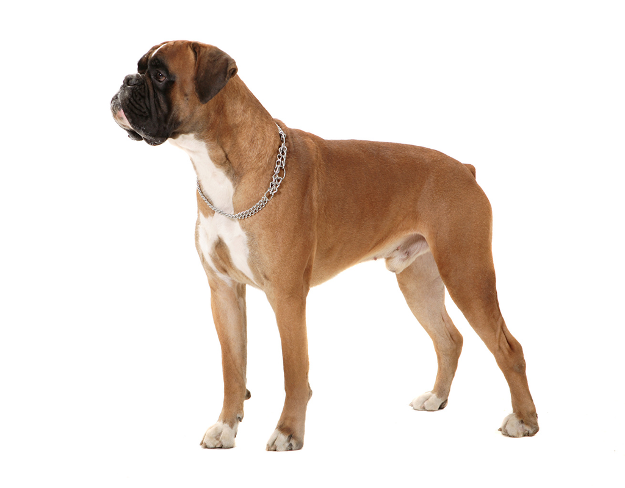

Boxer (L)

```r
knitr::include_graphics("dog/Boxer.jpg")
```

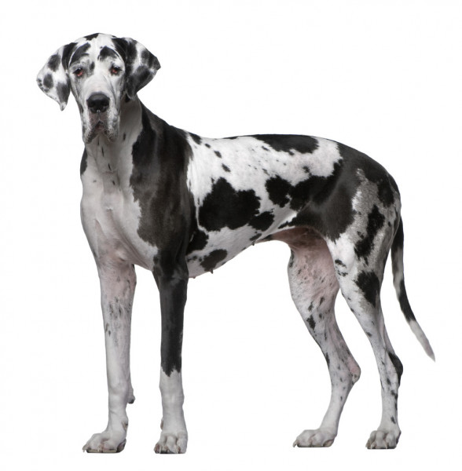

Great Dane (XL)

```r
knitr::include_graphics("dog/greatdane.jpg")
```

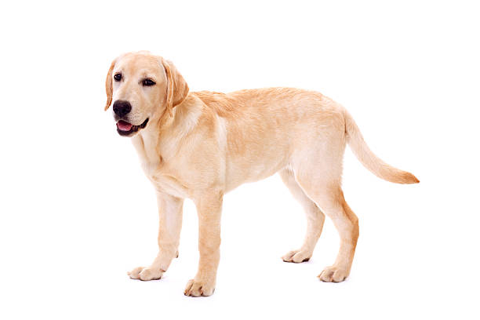

```r
knitr::include_graphics("dog/labret.jpg")
```

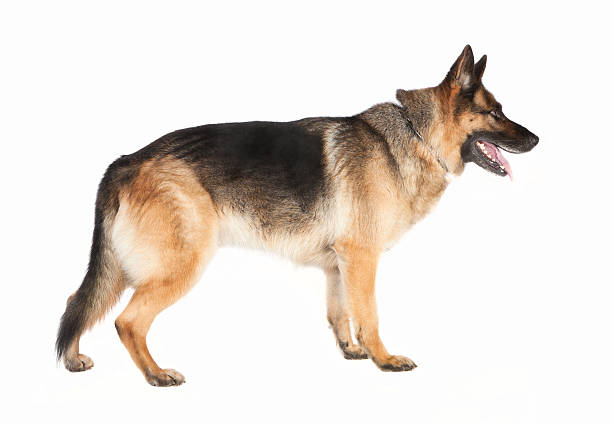

German Shepherd (L)

```r
knitr::include_graphics("dog/german_sheperd.jpg")
```

```r
#global variable
alignment_name<<-""

#notebook functions

#align fasta from file_name with names from name file (visualization purposes) after alignment displays msaprettyprint results for human readable data
mult_alingments<-function(file_name,fasta_names,name){

  #read in fasta for all dogs
  string_set<-readDNAStringSet(file=file_name,use.names=FALSE)

  #read in seq names as list
  table=read.table(fasta_names, header = FALSE, sep = "\n")[["V1"]]

  #update names for pretty print
  names(string_set)<-table

  #align unnamed seqs
  alignment<-msa(string_set,order="input")

  #update global variable so multiple pretty print runs dont overrun eachother
  alignment_name<<-gsub(" ", "", paste(name,".pdf"), fixed = TRUE)

  #return pretty alignment, does not show up on my console
  msaPrettyPrint(alignment, file=alignment_name,output="pdf",
                 showNames="right",showLogo="top",askForOverwrite=FALSE,
                 showNumbering="none",paperWidth=6,paperHeight=3)
  return(alignment_name)
}
#have figure with white background, no gridline and only axis ticks, no lines
tune_figure<-function(fig,addons){
  return(fig+theme_minimal()+theme(
    plot.background = element_blank(),
    panel.grid.major = element_blank(),
    panel.grid.minor = element_blank(),
    panel.border = element_blank()))
}
#create dendogram based on fasta files, names of items clustered in fasta_names
create_dendogram<-function(fasta_path, fasta_names, fig_title){
  #grab DNA info from coallated file
  dna <- string_set<-readDNAStringSet(file=fasta_path,use.names=FALSE)
  #get sequence names
  names(dna)=read.table(fasta_names, header = FALSE, sep = "\n")[["V1"]]
  #create distance matrix for clustering
  d1 <- DistanceMatrix(dna, type="dist")
  #form dendogram
  dendogram<-IdClusters(d1, method="complete", cutoff=0.05, showPlot=FALSE,type="dendrogram")
  #fix names being cut-off
  nodePar <- list(lab.cex = 0.6, pch = c(NA, 19),
                cex = 0.7, col = "black")
#plot results
plot(as.dendrogram(dendogram), ylab = "Height", nodePar =nodePar,main=fig_title)
  return(as.dendrogram(dendogram))
}
```

LCORL Analysis

```r
#LCORL CALL
alignment<-mult_alingments("fasta/LCORL_file.txt","fasta/names.txt","LCORL")
```

```
## use default substitution matrix
```

```r
print(alignment_name)
```

```
## [1] "LCORL.pdf"
```

[figure not shown]

```r
#IGF1 CALL
alignment<-mult_alingments("fasta/igf1.fasta","fasta/igf1_names.txt","igf1")
```

```
## use default substitution matrix
```

[figure not shown]

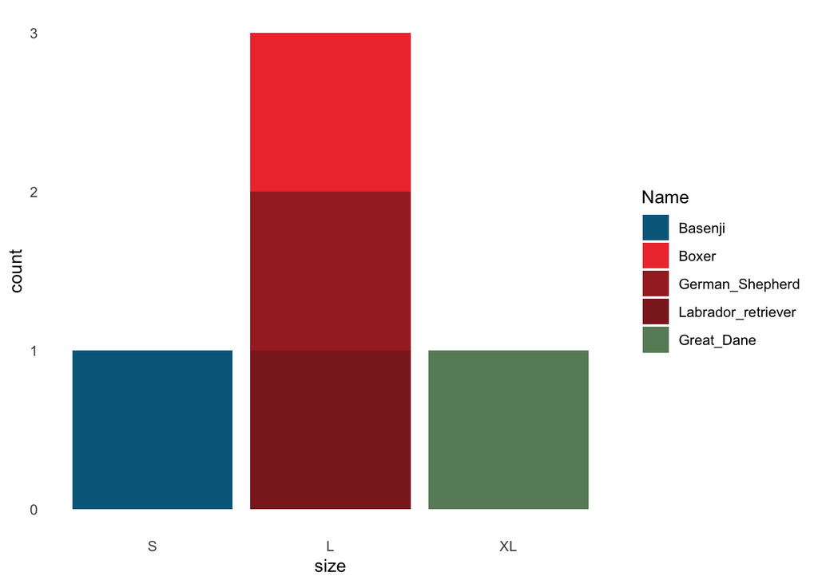

```r
#visualize size breakdown of dogs
snps<-read_excel("dog snps.xlsx")
#fix ordering of legend
snps$Name <- factor(snps$Name, levels = c("Basenji", "Boxer", "German_Shepherd","Labrador_retriever","Great_Dane"))
p<-ggplot(data = snps, aes(size))+scale_x_discrete(limits = c("S","L","XL"))+geom_bar(aes(fill = Name))+scale_fill_manual(values = c("deepskyblue4","brown2","brown","brown4","darkseagreen4"))
tune_figure(p,add_ons)
```

```r
abbrev_x <- c("A","C","'G","'T")
print(length(abbrev_x))
```

```
## [1] 4
```

```r
print(length(seq(0,4,by=1)))
```

```
## [1] 5
```

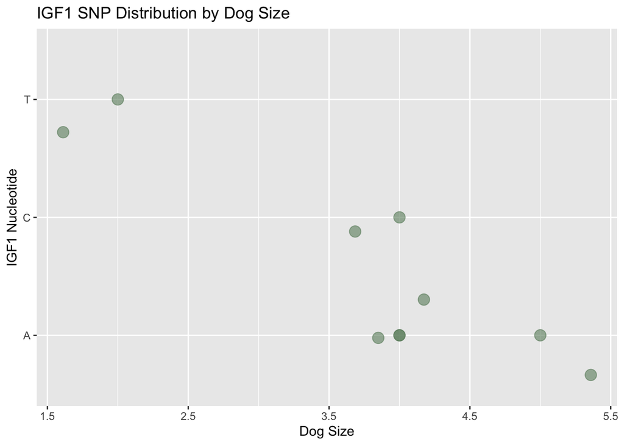

```r
#visualize IGF1 SNP by size
p<-ggplot(data = snps, mapping = aes(y=igf1,x=size_num))+geom_point(size=4,alpha=0.6,color="darkseagreen4")+labs(y="IGF1 Nucleotide", x = "Dog Size")+ggtitle("IGF1 SNP Distribution by Dog Size")
p+geom_jitter(size=4,alpha=0.6,color="darkseagreen4")
```

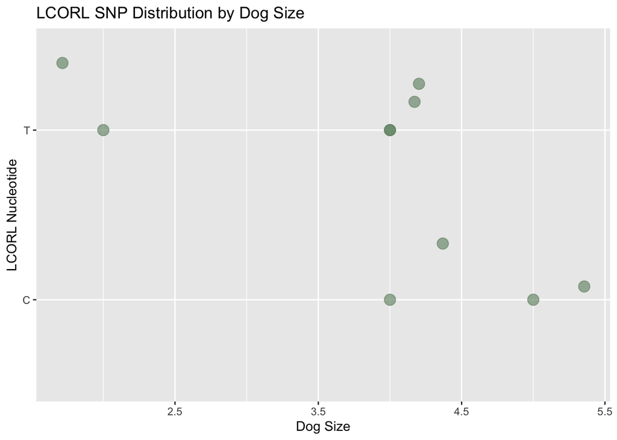

```r
#visualize LCORL SNP by size
p<-ggplot(data = snps, mapping = aes(y=lcorl,x=size_num))+geom_point(size=4,alpha=0.6,color="darkseagreen4")+ labs(y="LCORL Nucleotide", x = "Dog Size")+ggtitle("LCORL SNP Distribution by Dog Size")
p+geom_jitter(size=4,alpha=0.6,color="darkseagreen4")
```

```r
#Cluster LCORL extended fragment
create_dendogram("fasta/LCORL_file.txt", "fasta/names.txt", "LCORL Extended Fragment Dendogram")
```

```
## ================================================================================
##
## Time difference of 0 secs
##
## ================================================================================
##
## Time difference of 0.01 secs
```

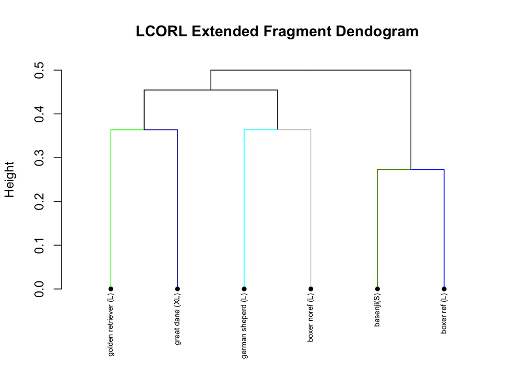

```
## 'dendrogram' with 2 branches and 6 members total, at height 0.5
```

http://www.sthda.com/english/wiki/beautiful-dendrogram-visualizations-in-r-5-must-known-methods-unsupervised-machine-learning#plot.dendrogram-function for look and non cut off stuff

```r
#Cluster IGF1 extended fragment
create_dendogram("fasta/igf1.fasta", "fasta/igf1_names.txt", "IGF1 Extended Fragment Dendogram")
```

```
## ================================================================================
##
## Time difference of 0 secs
##
## ================================================================================
##
## Time difference of 0 secs
```

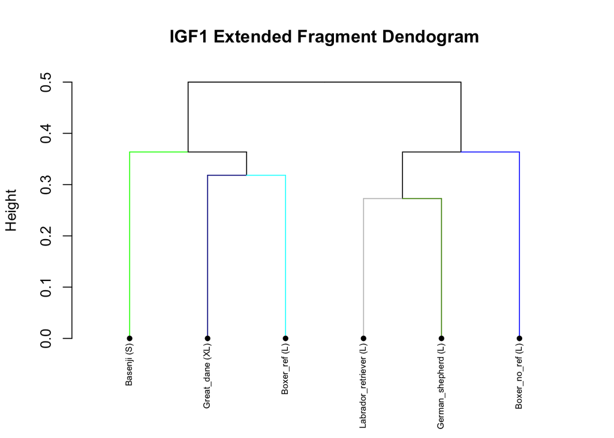

```
## 'dendrogram' with 2 branches and 6 members total, at height 0.5
```

```r
string_set<-readAAStringSet(file="fasta/IGSF1.fasta",use.names=TRUE)
#read in seq names as list
table=read.table("fasta/IGSF1_names.txt", header = FALSE, sep = "\n")[["V1"]]
#update names for pretty print
names(string_set)<-table
mult<-msa(string_set)
```

```
## use default substitution matrix
```

```r
library(seqinr)
library(ape)
names(mult)
```

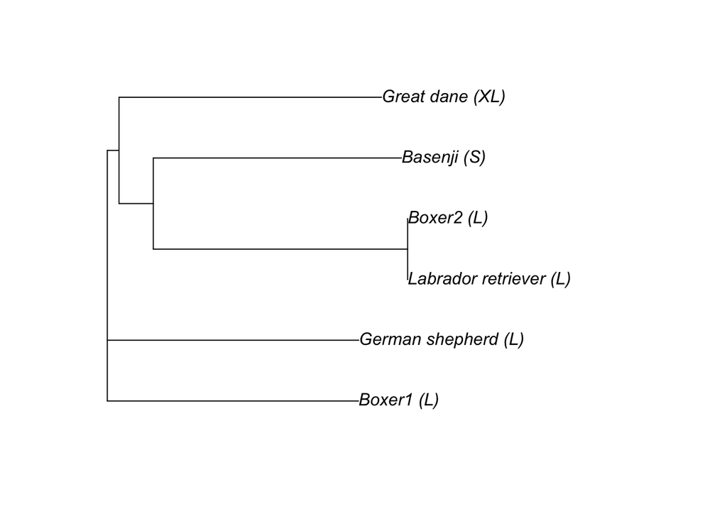

```r
igsf1_aln <- msaConvert(mult, type="seqinr::alignment")
d <- dist.alignment(igsf1_aln, "identity")
igsf1_tree <- nj(as.matrix(d))
plot(igsf1_tree)
```

```r
#x<-create_clusters("fasta/IGSF1.fasta", "fasta/IGSF1_names.txt", "TEST")
#plot(raise.dendrogram(x, 100))
#print(x)
#x<-create_clusters("fasta/igf1.fasta", "fasta/igf1_names.txt", "IGF1 Extended Fragment #Dendogram")
#tinytex::check_installed('pdflatex')
```